# Sample Size for Win Ratio

A simulation-based approach using WINS R package

Anthony Devaux (The George Institute for Global Health)

ICTMC 2026 Workshop

# 1 Packages

The following block of code will install the packages used in this docuement.

```r
required_packages <- c("dplyr", "WINS", "copula", "ggplot2", "furrr", "future", "dplyr")

for (pkg in required_packages) {
  if (!requireNamespace(pkg, quietly = TRUE)) {
    install.packages(pkg)
  }
  library(pkg, character.only = TRUE)
}
```

# 2 Simple sample size estimation

If you happen to be able to estimate the win ratio you target and the residual proportion of ties, you can derive the required sample size using a formula. The formula is implemented in different packages.

In this toy example:

- We seek WR = 1.5
- with 90% power
- at two-sided 5% significance level or one-sided 2.5% (see below)
- using 1:1 randomisation
- expecting 15% residual ties.

`Pass 2025` (Use module *Tests for Two Groups using the Win-Ratio Composite Endpoint*) gives 231 per arm, totalling 462 in a two-arm RCT.

Using `hce`:

```r
library(hce)

sizeWR(
  WR = 1.5,      # Win ratio = 1.5
  Pties = 0.15,  # 15% ties
  power = 0.9,   # Power = 90%
  k = 0.5,       # 1:1 randomisation
  alpha = 0.05,  # Two-sided alpha = 0.05
)
```

| WR | Pties | WO | power | SampleSize | alpha |
| --- | --- | --- | --- | --- | --- |
| 1.5 | 0.15 | 1.409639 | 0.9 | 462 | 0.05 |

We have N = 462.

Using `WRestimates`:

```r
library(WRestimates)

wr.ss(
  WR = 1.5,      # Win ratio = 1.5
  alpha = 0.025, # One-sided alpha = 0.025, NOTE difference to hce and PASS!
  beta = 0.10,   # Power = 90%
  k = 0.5,       # 1:1 randomisation
  p.tie = 0.15   # 15% ties
)
```

```
## $N
## [1] 462
##
## $alpha
## [1] 0.025
##
## $beta
## [1] 0.1
##
## $WR.true
## [1] 1.5
##
## $sigma.sqr
## [1] 7.215686
##
## $k
## [1] 0.5
##
## $p.tie
## [1] 0.15
```

Again we have N = 462. Please note well though the difference between `PASS 2025` and `hce` vs `WREstimates`. With `WREstimates` we had to halve the type-one error rate because it expects a one-sided alpha.

# 3 Simulation: the BREATHE-FREE scenario

In more complex situations, where we have no idea what WR we might observe, or how frequent ties will be, simulation is the tool to use. The rest of the document uses the BREATHE-FREE scenario we discussed in class to run some simulations, estimate WRs we could plausibly detect given our beliefs on hierarchy compomonent means, and power at different sample sizes.

As out hierarchy, we will use:

| Priority | Outcome |
| --- | --- |
| 1 | All-cause mortality |
| 2 | Severe exacerbations |
| 3 | Moderate exacerbations |
| 4 | 6-minute walk distance (6MWD) |

## 3.1 Outcome 1 - All-cause mortality

- **Outcome type**: Time-to-event
- **Distribution**: Exponential
- **Control-arm assumption**: 10% mortality by 24 months
- **Treatment effect**: Hazard ratio = 0.85 (~8.5% in treatment arm)

```r
# ASSUMPTIONS
followup_time <- 24

lambda_death_ctrl <- -log(1 - 0.10) / followup_time # rate parameter for Exponential distribution
hr_death <- 0.85 # hazard ratio
```

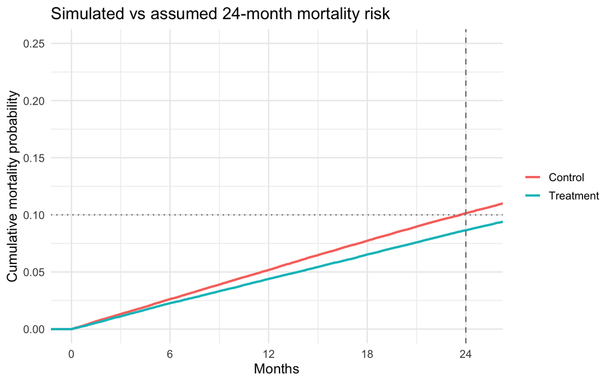

```r
set.seed(2026)
library(dplyr)
library(ggplot2)

# SIMULATE DATA
d_death <- bind_rows(
  data.frame(time = rexp(100000, rate = lambda_death_ctrl), arm = "Control"),
  data.frame(time = rexp(100000, rate = lambda_death_ctrl * hr_death),  arm = "Treatment")
)

# PLOT
ggplot(d_death, aes(x = time, colour = arm)) +
  stat_ecdf(geom = "step", linewidth = 1) +
  geom_vline(xintercept = followup_time, linetype = "dashed", colour = "grey50") +
  geom_hline(yintercept = 0.10, linetype = "dotted", colour = "grey50") +
  scale_x_continuous(breaks = seq(0, 24, 6)) +
  coord_cartesian(xlim = c(0, 25), ylim = c(0, 0.25)) +
  labs(x = "Months", y = "Cumulative mortality probability",
       title = "Simulated vs assumed 24-month mortality risk",
       colour = NULL) +
  theme_minimal(base_size = 13)
```

## 3.2 Outcome 2 - Severe exacerbations

- **Outcome type**: Count
- **Distribution**: Poisson
- **Control-arm assumption**: 0.8 event
- **Treatment effect**: Rate ratio = 0.70 (~0.56 events in the treatment arm)

```r
# ASSUMPTIONS
lambda_severe_ctrl <- 0.8 # mean parameter for Poisson distribution
rr_severe <- 0.70 # rate ratio
```

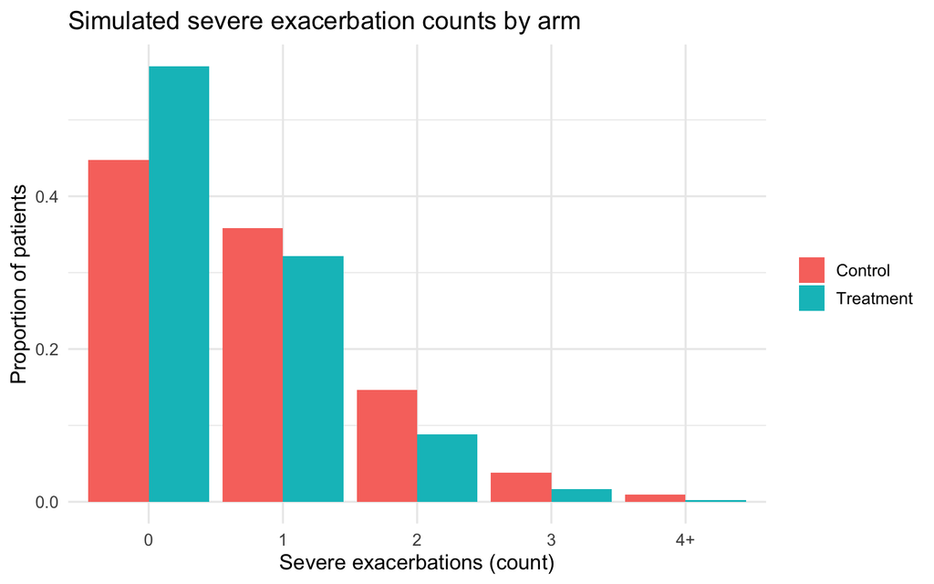

```r
set.seed(2026)

# SIMULATE DATA
d_exacer_sev <- bind_rows(
  data.frame(N_event = rpois(100000, lambda = lambda_severe_ctrl), arm = "Control"),
  data.frame(N_event = rpois(100000, lambda = lambda_severe_ctrl * rr_severe), arm = "Treatment")
) |>
  mutate(
    N_event_cat = pmin(N_event, 4),
    N_event_cat = factor(N_event_cat, levels = 0:4, labels = c("0","1","2","3","4+"))
  )

# GET PROPOTIONS
d_exacer_sev_prop <- d_exacer_sev |>
  count(arm, N_event_cat, name = "n") |>
  group_by(arm) |>
  mutate(prop = n / sum(n)) |>
  ungroup()

# PLOT
ggplot(d_exacer_sev_prop, aes(x = N_event_cat, y = prop, fill = arm)) +
  geom_col(position = "dodge") +
  labs(x = "Severe exacerbations (count)", y = "Proportion of patients", fill = NULL,
       title = "Simulated severe exacerbation counts by arm") +
  theme_minimal(base_size = 13)
```

## 3.3 Outcome 3 - Moderate exacerbations

- **Outcome type**: Count
- **Distribution**: Poisson
- **Control-arm assumption**: 2.0 events
- **Treatment effect**: Rate ratio = 0.80 (~1.6 events in the treatment arm)

```r
# ASSUMPTIONS
lambda_moderate_ctrl <- 2.0 # mean parameter for Poisson distribution
rr_moderate <- 0.80 # rate ratio
```

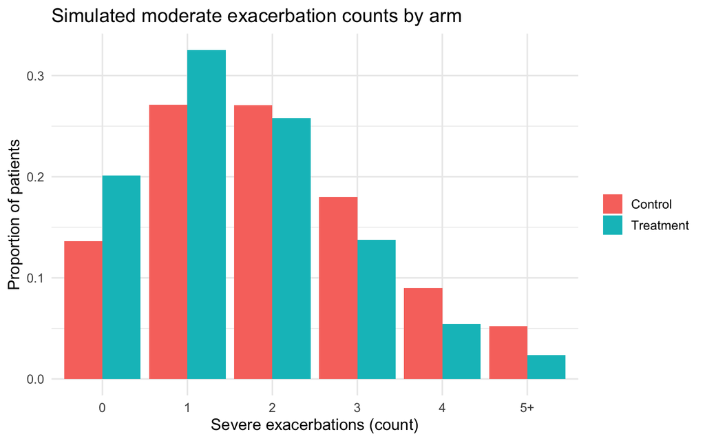

```r
# SIMULATE DATA
d_exacer_mod <- bind_rows(
  data.frame(N_event = rpois(100000, lambda = lambda_moderate_ctrl), arm = "Control"),
  data.frame(N_event = rpois(100000, lambda = lambda_moderate_ctrl * rr_moderate), arm = "Treatment")
) |>
  mutate(
    N_event_cat = pmin(N_event, 5),
    N_event_cat = factor(N_event_cat, levels = 0:5, labels = c("0","1","2","3","4","5+"))
  )

# GET PROPOTIONS
d_exacer_mod_prop <- d_exacer_mod |>
  count(arm, N_event_cat, name = "n") |>
  group_by(arm) |>
  mutate(prop = n / sum(n)) |>
  ungroup()

# PLOT
ggplot(d_exacer_mod_prop, aes(x = N_event_cat, y = prop, fill = arm)) +
  geom_col(position = "dodge") +
  labs(x = "Severe exacerbations (count)", y = "Proportion of patients", fill = NULL,
       title = "Simulated moderate exacerbation counts by arm") +
  theme_minimal(base_size = 13)
```

## 3.4 Outcome 4: 6-minute walk distance

- **Outcome type**: Continuous
- **Distribution**: Normal
- **Control-arm assumption**: Mean = 250 / SD = 60
- **Treatment effect**: Mean difference = 30 (mean = 280 in treatment arm, assume same SD)

```r
# ASSUMPTIONS
walk_mean_ctrl <- 250
walk_mean_trt  <- 280
walk_sd <- 60
```

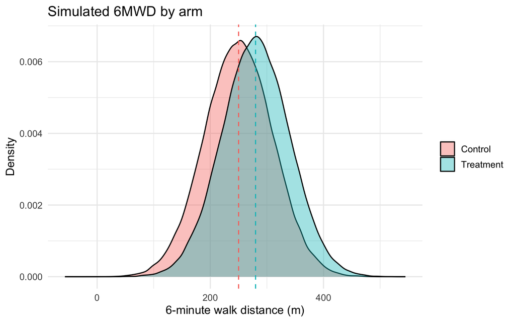

```r
set.seed(2026)

# SIMULATE DATA
d_6mwd <- bind_rows(
  data.frame(walk_distance = rnorm(100000, mean = walk_mean_ctrl, sd = walk_sd), arm = "Control"),
  data.frame(walk_distance = rnorm(100000, mean = walk_mean_trt, sd = walk_sd), arm = "Treatment")
)

# PLOT
ggplot(d_6mwd, aes(x = walk_distance, fill = arm)) +
  geom_density(alpha = 0.4) +
  geom_vline(xintercept = c(walk_mean_ctrl, walk_mean_trt), linetype = "dashed",
             colour = c("#F8766D", "#00BFC4")) +
  labs(x = "6-minute walk distance (m)", y = "Density", fill = NULL,
       title = "Simulated 6MWD by arm") +
  theme_minimal(base_size = 13)
```

## 3.5 Dependence structure across outcomes

**Dependence between outcomes**:

- mortality vs. either exacerbation count: **negative** correlation (longer survival goes with fewer exacerbations)
- mortality vs. 6MWD: **positive** correlation (both move with overall health in the same direction)
- severe vs. moderate exacerbations: **positive** correlation (shared disease severity drives both)
- either exacerbation count vs. 6MWD: **negative** correlation

|  | Mortality | Severe | Moderate | Walk |
| --- | --- | --- | --- | --- |
| **Mortality** | 1.00 | -0.35 | -0.20 | 0.30 |
| **Severe** | -0.35 | 1.00 | 0.45 | -0.30 |
| **Moderate** | -0.20 | 0.45 | 1.00 | -0.15 |
| **Walk** | 0.30 | -0.30 | -0.15 | 1.00 |

```r
library(copula)

# CORRELATION STRUCTURE
rho <- c(mort_severe     = -0.35,
         mort_moderate   = -0.20,
         mort_walk       =  0.30,
         severe_moderate =  0.45,
         severe_walk     = -0.30,
         moderate_walk   = -0.15)


cop_trt <- normalCopula(param = rho, dim = 4, dispstr = "un")
#cop_trt <- normalCopula(param = 0, dim = 4) # assuming no correlation
cop_con <- cop_trt   # assume the same dependence structure in both arms

margins_trt <- c("exp", "pois", "pois", "norm")
paramMargins_trt <- list(
  list(rate = lambda_death_ctrl * hr_death),
  list(lambda = lambda_severe_ctrl * rr_severe),
  list(lambda = lambda_moderate_ctrl * rr_moderate),
  list(mean = walk_mean_trt, sd = walk_sd)
)

margins_con <- c("exp", "pois", "pois", "norm")
paramMargins_con <- list(
  list(rate = lambda_death_ctrl),
  list(lambda = lambda_severe_ctrl),
  list(lambda = lambda_moderate_ctrl),
  list(mean = walk_mean_ctrl, sd = walk_sd)
)
```

## 3.6 Simulate data using `sim.data()`

```r
library(WINS)

# SIMULATE ALL OUTCOMES
data_simu <- sim.data(
  randomseed = 2026, n_trt = 100, n_con = 100, n_ep = 4,
  arm.name = c("trt", "con"),
  ep_type = c("tte", "continuous", "continuous", "continuous"), # outcome type
  cdist.rate = 0.02, # rate for lost of follow-up
  sim_method = "copula",
  copula_trt = cop_trt,
  margins_trt = margins_trt,
  paramMargins_trt = paramMargins_trt,
  copula_con = cop_con,
  margins_con = margins_con,
  paramMargins_con = paramMargins_con
)

head(data_simu, 10)
```

| arm | stratum | Delta_1 | Y_1 | Y_2 | Y_3 | Y_4 |
| --- | --- | --- | --- | --- | --- | --- |
| trt | 1 | 0 | 9.561289 | 0 | 1 | 229.7361 |
| trt | 1 | 0 | 96.502620 | 0 | 0 | 375.9445 |
| trt | 1 | 1 | 45.071445 | 0 | 0 | 213.6369 |
| trt | 1 | 0 | 93.035706 | 1 | 1 | 263.3688 |
| trt | 1 | 0 | 42.465440 | 2 | 6 | 197.5930 |
| trt | 1 | 0 | 82.861381 | 2 | 2 | 330.3739 |
| trt | 1 | 1 | 10.997577 | 1 | 1 | 253.6339 |
| trt | 1 | 0 | 26.293154 | 1 | 1 | 431.2864 |
| trt | 1 | 0 | 1.444337 | 0 | 2 | 279.2530 |
| trt | 1 | 1 | 34.640182 | 1 | 3 | 286.0029 |

```r
# TIME TO EVENT OUTCOMES NOT AUTOMATICALLY CENSORED AT END OF STUDY TIME (24 MONTHS)
data_simu$Delta_1[data_simu$Y_1>24] <- 0
data_simu$Y_1[data_simu$Y_1>24] <- 24
```

## 3.8 Power calculation function

Each replication is wrapped in `run_one_rep()` and dispatched with `furrr::future_map_dfr()`, so the `nsim` replications for a given scenario are spread across parallel workers rather than looped over sequentially.

```r
power_at_n <- function(n_per_arm = 150, hr_death = 0.85, rr_severe = 0.70, nsim = 100, seed0 = 2026) {

  # only the mortality and severe-exacerbation treatment margins change with
  # the assumptions being varied - moderate exacerbations and 6MWD stay fixed
  paramMargins_trt_sens <- list(
    list(rate = lambda_death_ctrl * hr_death),
    list(lambda = lambda_severe_ctrl * rr_severe),
    list(lambda = lambda_moderate_ctrl * rr_moderate),
    list(mean = walk_mean_trt, sd = walk_sd)
  )

  # ---- one replication, returned as a 1-row data.frame ----
  run_one_rep <- function(i) {

    # simulate data
    data_simu <- sim.data(
      randomseed = seed0 + i, n_trt = n_per_arm, n_con = n_per_arm, n_ep = 4,
      arm.name = c("trt", "con"),
      ep_type = c("tte", "continuous", "continuous", "continuous"),
      cdist.rate = 0.02,
      sim_method = "copula",
      copula_trt = cop_trt,
      margins_trt = margins_trt,
      paramMargins_trt = paramMargins_trt_sens,
      copula_con = cop_con,
      margins_con = margins_con,
      paramMargins_con = paramMargins_con
    )

    # censor at 24 months (end of study)
    data_simu$Delta_1[data_simu$Y_1>24] <- 0
    data_simu$Y_1[data_simu$Y_1>24] <- 24

    # perform win-ratio analysis
    res <- win.stat(
        data = data_simu,
        ep_type = c("tte", "continuous", "continuous", "continuous"),
        arm.name = c("trt", "con"),
        priority = c(1, 2, 3, 4), # outcome hierarchy
        tau = c(0, 0, 0, 0),
        np_direction = c("larger", "smaller", "smaller", "larger"), # direction to win
        pvalue = "two-sided", digit = 5, summary.print = FALSE
      )

    data.frame(
      reject = res$p_value$pvalue_WR < 0.05,
      wr     = res$Win_statistic$Win_Ratio["WR"]
    )

  }

  rep_res <- future_map_dfr(
    seq_len(nsim),
    run_one_rep,
    .options = furrr_options(seed = TRUE) # ensures proper RNG stream per worker
  )

  out <- data.frame(power = mean(rep_res$reject), mean_WR = mean(rep_res$wr))

  return(out)

}
```

## 3.9 Different scenarios

- **Number of subjects per arm**: 100, 150, 200
- **HR for mortality outcome**: 0.75, 0.85
- **RR for severe exacerbation**: 0.7, 0.8

```r
library(furrr)

# START PARALLEL WORKERS - reused across all scenarios below
plan(multisession, workers = max(1, parallel::detectCores() - 1))
```

The following chunk takes a few minutes to run:

```r
# SCENARIO DATASET
sensitivity_grid <- expand.grid(
  n_per_arm = c(100, 150, 200),
  hr_death  = c(0.75, 0.85),
  rr_severe = c(0.7, 0.8)
)

# RUN SIMULATIONS FOR ALL SCENARIOS
sensitivity_results <- lapply(seq_len(nrow(sensitivity_grid)), function(i) {

  scenario_i <- sensitivity_grid[i, ]

  simu_res <- power_at_n(n_per_arm = scenario_i$n_per_arm, hr_death = scenario_i$hr_death, rr_severe = scenario_i$rr_severe, nsim = 100)

  out <- scenario_i |>
    dplyr::mutate(
      power = simu_res$power,
      mean_WR = simu_res$mean_WR
    )

  return(out)

}) |>
  bind_rows()
```

[output not shown]

[output cut: 1145 more lines]

[output not shown]

```r
sensitivity_results
```

| n_per_arm | hr_death | rr_severe | power | mean_WR |
| --- | --- | --- | --- | --- |
| 100 | 0.75 | 0.7 | 0.72 | 1.554271 |
| 150 | 0.75 | 0.7 | 0.85 | 1.485858 |
| 200 | 0.75 | 0.7 | 0.93 | 1.508889 |
| 100 | 0.85 | 0.7 | 0.71 | 1.538482 |
| 150 | 0.85 | 0.7 | 0.85 | 1.469547 |
| 200 | 0.85 | 0.7 | 0.92 | 1.492077 |
| 100 | 0.75 | 0.8 | 0.51 | 1.435177 |
| 150 | 0.75 | 0.8 | 0.66 | 1.372311 |
| 200 | 0.75 | 0.8 | 0.79 | 1.391478 |
| 100 | 0.85 | 0.8 | 0.51 | 1.421923 |
| 150 | 0.85 | 0.8 | 0.61 | 1.358656 |
| 200 | 0.85 | 0.8 | 0.77 | 1.376802 |

```r
# STOP PARALLEL WORKERS - release once all scenarios are done
plan(sequential)
```

**Runtime note**: Only 100 replications are performed per scenario for this example, but in practice, this should be run across 10,000 replications. The `nsim` replications within each scenario are now run in parallel via `furrr`/`future` (see `power_at_n()` above), which substantially reduces computation time; the 12 scenarios in `sensitivity_grid` are still evaluated one at a time via `lapply()`, so each scenario’s replications share the full pool of workers in turn.

## 3.10 Visualize power and sample size

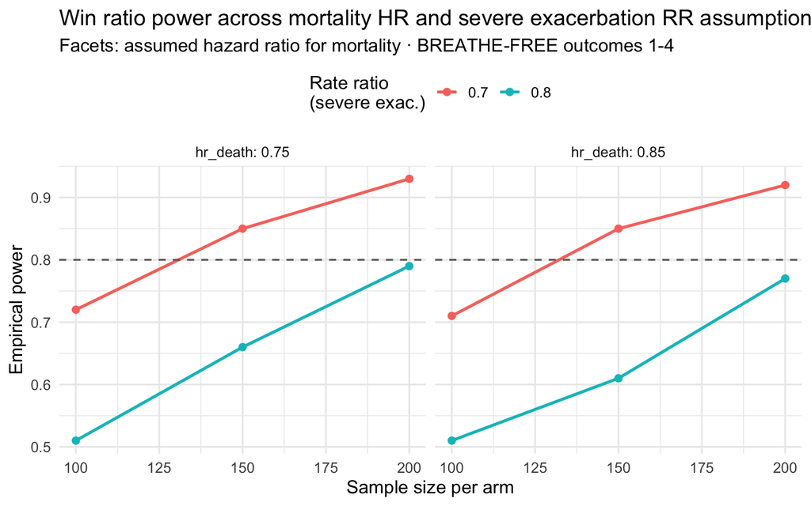

```r
ggplot(sensitivity_results, aes(x = n_per_arm, y = power, colour = factor(rr_severe))) +
  geom_line(linewidth = 1) +
  geom_point(size = 2) +
  geom_hline(yintercept = 0.80, linetype = "dashed", colour = "grey40") +
  facet_wrap(~ hr_death, labeller = label_both) +
  labs(
    x = "Sample size per arm",
    y = "Empirical power",
    colour = "Rate ratio\n(severe exac.)",
    title = "Win ratio power across mortality HR and severe exacerbation RR assumptions",
    subtitle = "Facets: assumed hazard ratio for mortality \u00B7 BREATHE-FREE outcomes 1-4"
  ) +
  theme_minimal(base_size = 13) +
  theme(legend.position = "top")
```